# Análisis de supervivencia

2022-05-06

## Estimador Kaplan-Meier

### Primeros ejemplos

Consideremos primero un ejemplo en el cual sólo tenemos fallas y no censuras, y el tiempo de supervivencia es:

$$10 \ \ 22\ \ 29\ \ 37\ \ 45\ \ 51\ \ 52\ \ 52\ \ 64\ \ 79$$
donde sólo hay una falla entre cada intervalo. Calculamos el estimador de Kaplan-Meier para la función de supervivencia como sigue:

- $t=0:$ $(10/10)=1$
- $t=10:$ $(10/10)\cdot(9/10)=0.9$. Pues sobreviven 9 sujetos de los 10 que teníamos, dado que uno ya falló.
- $t=22:$ $(10/10)\cdot(9/10)\cdot (8/9)=0.8$. Pues sobreviven 8 sujetos de los 9 que teníamos, dado que uno ya falló. $\vdots$
- $t=52:$ $(10/10)\cdot(9/10)\cdot(8/9)\cdot (7/8) \cdot (4/5)\cdot (2/4)=0.2$. Agregamos al final el $(2/4)$ puesto que tuvimos un empate, es decir, en $t=52$ ocurrieron dos fallas por lo cual quedaron 2 sujetos de los 4 que teníamos.

Y continuamos así sucesivamente. En *R* implementamos el análisis anterior como sigue:

```r
# Funcion de supervivencia: Kaplan-Meier

# Cargamos la librería necesaria
library(survival)

# Definimos el tiempo de supervivencia
tiempo = c(10,22,29,37,45,51,52,52,64,79)
```

Luego, utilizaremos una función indicadora para identificar las censuras y las fallas:

$$\mathbb{I}(w)=\left\{\begin{array}&1 \ \ \textrm{si w es falla}\\0 \
\ \textrm{si w es censura}\end{array}\right.$$

por lo cual tenemos que

```r
# Definimos un vector de censuras y fallas.
# En este caso es sólo un vector de fallas

censura = c(1,1,1,1,1,1,1,1,1,1)
```

Después utilizamos la función *Surv()*

```r
Surv(tiempo,censura)
```

```
##  [1] 10 22 29 37 45 51 52 52 64 79
```

para juntar el tiempo de supervivencia con las fallas correspondientes a cad tiempo (que en este caso es una falla por tiempo). Proseguimos realizando el ajuste del estimador Kaplan-Meier:

```r
ajuste <- survfit(Surv(tiempo,censura)~1, type = "kaplan-meier", conf.type="none")

summary(ajuste)
```

```
## Call: survfit(formula = Surv(tiempo, censura) ~ 1, type = "kaplan-meier",
##     conf.type = "none")
##
##  time n.risk n.event survival std.err
##    10     10       1      0.9  0.0949
##    22      9       1      0.8  0.1265
##    29      8       1      0.7  0.1449
##    37      7       1      0.6  0.1549
##    45      6       1      0.5  0.1581
##    51      5       1      0.4  0.1549
##    52      4       2      0.2  0.1265
##    64      2       1      0.1  0.0949
##    79      1       1      0.0     NaN
```

```r
ajuste$surv
```

```
## [1] 0.9 0.8 0.7 0.6 0.5 0.4 0.2 0.1 0.0
```

y vemos que se obtiene los resultados (algunos) que ya habíamos obtenido antes.

Ahora continuamos con un ejemplo incluyendo censuras:

$$10 \ \ 22\ \ 25^{+} \ \ 29\ \ 37\ \ 45^{+}\ \ 45 \ \ 51\ \ 52\ \ 52\ \
64\ \ 79$$
donde el superíndice + indica que en dicho tiempo de supervivencia se presentó una censura. Para los casos en que se presenta censura, la función de supervivencia se mantiene igual. Por ejemplo, en el tiempo $t=22$ tenemos que $\hat{S}(t)=0.833$ y en $t=25^{+}$ se tiene igual que $\hat{S}(t)=0.833$. En *R* tenemos que:

```r
# Funcion de supervivencia: Kaplan-Meier

tiempo = c(10,22,25,29,37,45,45,51,52,52,64,79)
censura = c(1,1,0,1,1,1,0,1,1,1,1,1)
Surv(tiempo,censura)
```

```
##  [1] 10  22  25+ 29  37  45  45+ 51  52  52  64  79
```

vemos que en automático *R* indica que se presentó una censura en el tiempo $t=25$ y $t=45$. Luego

```r
ajuste <- survfit(Surv(tiempo,censura)~1, type = "kaplan-meier", conf.type="none")

summary(ajuste)
```

```
## Call: survfit(formula = Surv(tiempo, censura) ~ 1, type = "kaplan-meier",
##     conf.type = "none")
##
##  time n.risk n.event survival std.err
##    10     12       1    0.917  0.0798
##    22     11       1    0.833  0.1076
##    29      9       1    0.741  0.1295
##    37      8       1    0.648  0.1426
##    45      7       1    0.556  0.1493
##    51      5       1    0.444  0.1554
##    52      4       2    0.222  0.1356
##    64      2       1    0.111  0.1038
##    79      1       1    0.000     NaN
```

```r
ajuste$surv
```

```
##  [1] 0.9166667 0.8333333 0.8333333 0.7407407 0.6481481 0.5555556 0.4444444
##  [8] 0.2222222 0.1111111 0.0000000
```

y notamos que se omiten los tiempos donde ocurrieron censuras.

### Otro ejemplo

Continuaremos con el ejemplo de la clase pasada

```r
uis <- read.csv("uis.csv")
head(uis)
```

```
##   id age  beck hercoc ivhx ndrugtx race treat site time censor
## 1  1  39  9.00      4    3       1    0     1    0  188      1
## 2  2  33 34.00      4    2       8    0     1    0   26      1
## 3  3  33 10.00      2    3       3    0     1    0  207      1
## 4  4  32 20.00      4    3       1    0     0    0  144      1
## 5  5  24  5.00      2    1       5    1     1    0  551      0
## 6  6  30 32.55      3    3       1    0     1    0   32      1
```

y comenzamos por realizar el ajuste para la función de supervivencia mostrando los respectivos intervalos de confianza:

```r
# Funcion de supervivencia: Kaplan-Meier

ajuste <- survfit(Surv(time, censor)~1, type = "kaplan-meier", conf.type="log-log", conf.int=0.95, data=uis)

summary(ajuste)
```

```
## Call: survfit(formula = Surv(time, censor) ~ 1, data = uis, type = "kaplan-meier",
##     conf.type = "log-log", conf.int = 0.95)
##
##  time n.risk n.event survival std.err lower 95% CI upper 95% CI
##     4    575       2    0.997 0.00246        0.986        0.999
##     6    573       2    0.993 0.00347        0.982        0.997
##     7    571       4    0.986 0.00488        0.972        0.993
##     8    567       1    0.984 0.00518        0.970        0.992
##     9    566       1    0.983 0.00545        0.968        0.991
##    10    565       3    0.977 0.00620        0.961        0.987
##    11    562       2    0.974 0.00665        0.957        0.984
##    12    560       2    0.970 0.00706        0.953        0.982
##    14    558       4    0.963 0.00782        0.945        0.976
##    15    554       2    0.960 0.00817        0.940        0.973
##    18    552       1    0.958 0.00834        0.938        0.972
```

[output cut: 257 more lines]

y graaficamos el estimador con sus respectivos intervalos de confianza

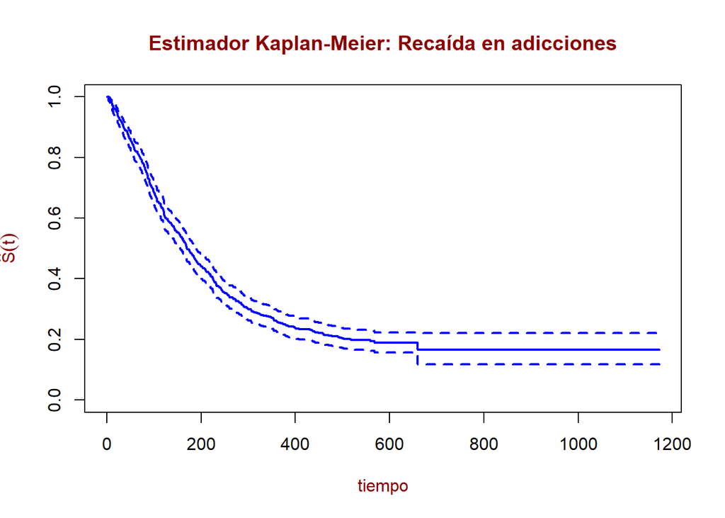

```r
plot(ajuste, main="Estimador Kaplan-Meier: Recaída en adicciones", xlab="tiempo", ylab=expression(hat(S)(t)), col="blue", col.main="darkred", col.lab="darkred", conf.int=T, lwd=2)
```